# Model Selection Exercise

Sarah K. Krueger

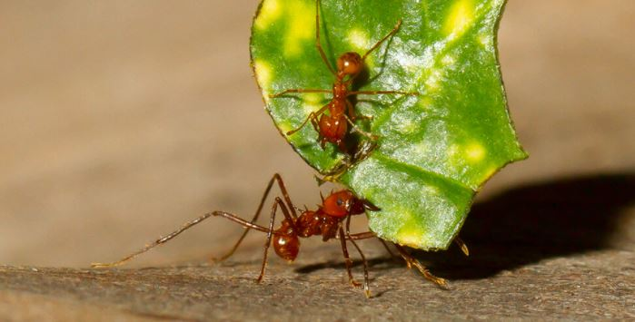

The goal of this first study was to investigate mound site preference of leaf cutter ants (*Atta cephalotes*) in Belize. A total of 10 mounds were surveyed and 10 randomized control sites were selected that did not have any mounds. The data includes one response variable: presence, and four predictor variables: distance to forest edge (m), sun exposure (%), elevation (ft), and soil pH.

```r
ants <- read.csv("ants.csv")
```

Firstly, I checked for co-linearity among the four predictor variables.

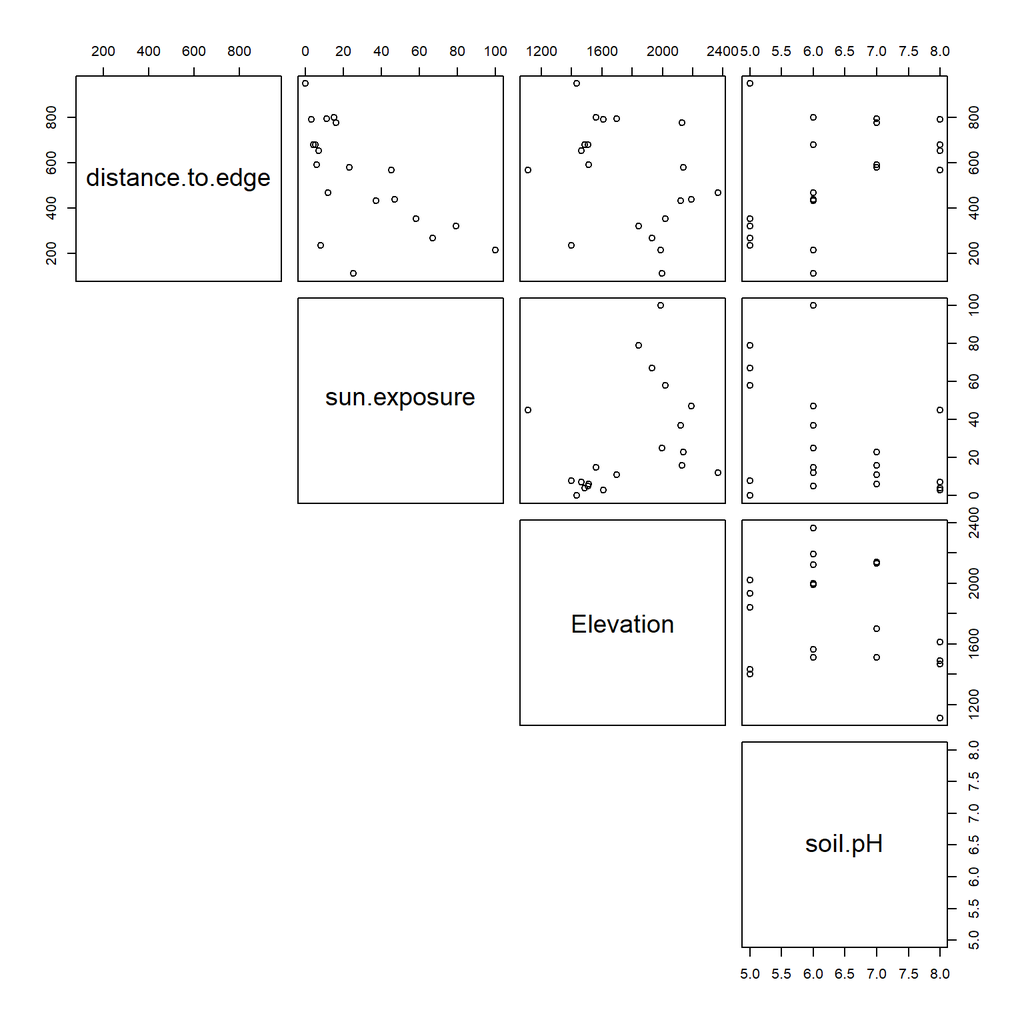

```r
pairs(ants[,2:5], lower.panel = NULL)
```

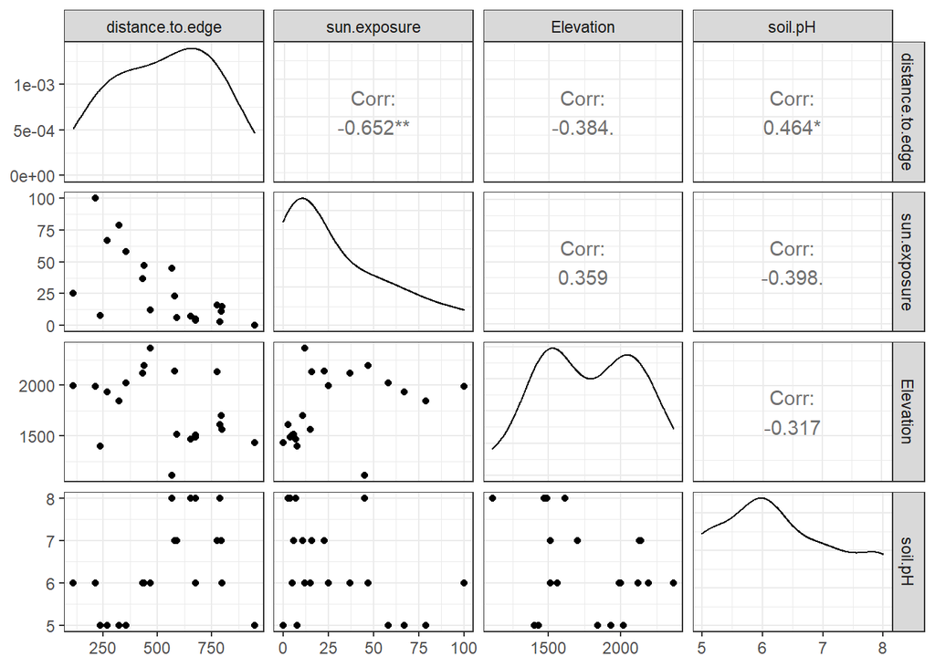

```r
ggpairs(ants, columns = 2:5) + theme_bw()
```

Sun exposure (%) and distance to edge (m) are highly correlated but for the purposes of this assignment, I chose to ignore it and run my candidate models next. (Note: Since the response variable was binary, I had to run a generalized linear model)

```r
mod1 <- glm(presence ~ Elevation + distance.to.edge + sun.exposure + soil.pH , family = binomial(link = "logit"), data = ants)
mod2 <- glm(presence ~ soil.pH + distance.to.edge + sun.exposure, family = binomial(link = "logit"), data = ants)
mod3 <- glm(presence ~ Elevation + distance.to.edge, family = binomial(link = "logit"), data = ants)
mod4 <- glm(presence ~ sun.exposure + soil.pH, family = binomial(link = "logit"), data = ants)
```

I then used the `model.sel` function to conduct model selection.

```r
out.put <- model.sel(mod1,mod2,mod3,mod4)
out.put
```

```
## Model selection table
##         (Int) dst.to.edg      Elv sol.pH sun.exp          family df  logLik
## mod4 -22.4100                      2.450  0.3289 binomial(logit)  3  -4.217
## mod2 -22.3100  -0.005486           2.988  0.2795 binomial(logit)  4  -3.754
## mod1 -41.3200  -0.009036 0.004540  4.822  0.2581 binomial(logit)  5  -3.554
## mod3   0.9191  -0.005648 0.001189                binomial(logit)  3 -10.067
##      AICc delta weight
## mod4 15.9  0.00  0.717
## mod2 18.2  2.24  0.234
## mod1 21.4  5.46  0.047
## mod3 27.6 11.70  0.002
## Models ranked by AICc(x)
```

Looks like model 4 containing an intercept (Int), soil pH, and sun exposure (sun.exp) is best model with a weight of 0.717. It is 0.717/0.234 = 3.06 times more likely to be the best explanation (hypothesis) for variation in mound presence.

I then used the `subset` function to select the models that meet the criteria of having a delta value <5.

```r
subset(out.put, delta <5)
```

```
## Model selection table
##       (Int) dst.to.edg sol.pH sun.exp          family df logLik AICc delta
## mod4 -22.41             2.450  0.3289 binomial(logit)  3 -4.217 15.9  0.00
## mod2 -22.31  -0.005486  2.988  0.2795 binomial(logit)  4 -3.754 18.2  2.24
##      weight
## mod4  0.754
## mod2  0.246
## Models ranked by AICc(x)
```

To re-normalize the weights, I used Royall’s 1/8 rule for strength of evidence.

```r
subset(out.put, 1/8 < weight/max(out.put$weight))
```

```
## Model selection table
##       (Int) dst.to.edg sol.pH sun.exp          family df logLik AICc delta
## mod4 -22.41             2.450  0.3289 binomial(logit)  3 -4.217 15.9  0.00
## mod2 -22.31  -0.005486  2.988  0.2795 binomial(logit)  4 -3.754 18.2  2.24
##      weight
## mod4  0.754
## mod2  0.246
## Models ranked by AICc(x)
```

The weights did not change, so I tried selecting models with 95% cumulative weight.

```r
subset(out.put, cumsum(out.put$weight) <= .95)
```

```
## Model selection table
##       (Int) sol.pH sun.exp          family df logLik AICc delta weight
## mod4 -22.41   2.45  0.3289 binomial(logit)  3 -4.217 15.9     0      1
## Models ranked by AICc(x)
```

We can see that this function has narrowed the model selection down to one.

I then cleaned up the data below.

```r
sel.table<-as.data.frame(out.put)[6:10]
sel.table[,2:3]<- round(sel.table[,2:3],2)
sel.table[,4:5]<- round(sel.table[,4:5],3)
names(sel.table)[2] = "K"
sel.table
```

```
##               family K logLik   AICc  delta
## mod4 binomial(logit) 3  -4.22 15.935  0.000
## mod2 binomial(logit) 4  -3.75 18.174  2.239
## mod1 binomial(logit) 5  -3.55 21.393  5.458
## mod3 binomial(logit) 3 -10.07 27.634 11.700
```

I then ran model selection sorted by BIC, CAICF, and AIC.

```r
model.sel(mod1,mod2,mod3,mod4, rank = BIC)
```

```
## Model selection table
##         (Int) dst.to.edg      Elv sol.pH sun.exp          family df  logLik
## mod4 -22.4100                      2.450  0.3289 binomial(logit)  3  -4.217
## mod2 -22.3100  -0.005486           2.988  0.2795 binomial(logit)  4  -3.754
## mod1 -41.3200  -0.009036 0.004540  4.822  0.2581 binomial(logit)  5  -3.554
## mod3   0.9191  -0.005648 0.001189                binomial(logit)  3 -10.067
##       BIC delta weight
## mod4 17.4  0.00  0.687
## mod2 19.5  2.07  0.244
## mod1 22.1  4.66  0.067
## mod3 29.1 11.70  0.002
## Models ranked by BIC(x)
```

```r
model.sel(mod1,mod2,mod3,mod4, rank = CAICF)
```

```
## Model selection table
##         (Int) dst.to.edg      Elv sol.pH sun.exp          family df  logLik
## mod4 -22.4100                      2.450  0.3289 binomial(logit)  3  -4.217
## mod2 -22.3100  -0.005486           2.988  0.2795 binomial(logit)  4  -3.754
## mod1 -41.3200  -0.009036 0.004540  4.822  0.2581 binomial(logit)  5  -3.554
## mod3   0.9191  -0.005648 0.001189                binomial(logit)  3 -10.067
##      CAICF delta weight
## mod4  26.6  0.00  0.999
## mod2  40.5 13.83  0.001
## mod1  55.1 28.48  0.000
## mod3  60.8 34.20  0.000
## Models ranked by CAICF(x)
```

```r
AIC(mod1,mod2, mod3, mod4)
```

```
##      df      AIC
## mod1  5 17.10723
## mod2  4 15.50761
## mod3  3 26.13443
## mod4  3 14.43485
```

Next, I ran the importance weights for individual predictor variables.

```r
importance(out.put)
```

```
##                      soil.pH sun.exposure distance.to.edge Elevation
## Sum of weights:      1.00    1.00         0.28             0.05
## N containing models:    3       3            3                2
```

Looking at the output above, there is plenty of evidence for *soil pH* and *sun exposure* (weights are one), but much less for *elevation*.

I then used the function `model.avg` to model average using all candidate models.

```r
MA.ests<-model.avg(out.put, revised.var = TRUE)
MA.ests
```

```
##
## Call:
## model.avg(object = out.put, revised.var = TRUE)
##
## Component models:
## '34'   '134'  '1234' '12'
##
## Coefficients:
##        (Intercept) sun.exposure  soil.pH distance.to.edge   Elevation
## full     -23.22625    0.3133351 2.682221     -0.001718533 0.000214970
## subset   -23.22625    0.3139837 2.687773     -0.006074385 0.004398097
```

I plotted a graph with the “best” model.

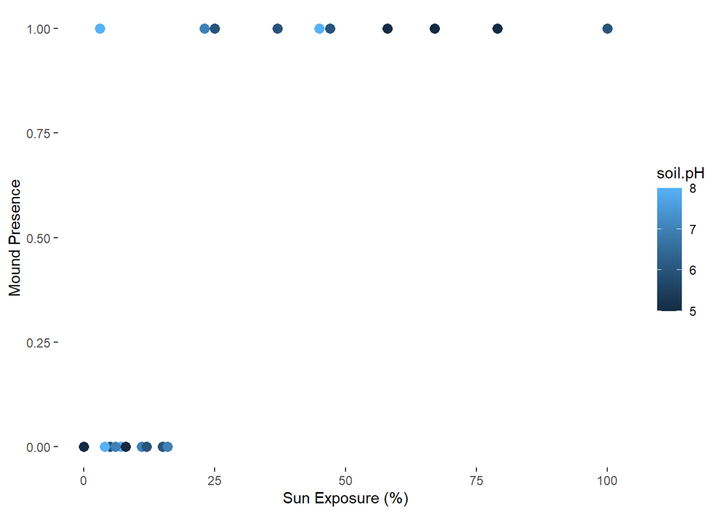

```r
p1 <- ggplot(ants, aes(sun.exposure, presence, color = soil.pH)) +
  geom_point(size = 3) +
  xlab("Sun Exposure (%)") +
  ylab("Mound Presence") +
  theme(panel.grid.major = element_blank(),
        panel.grid.minor = element_blank(),
        panel.background = element_blank())

p1
```

Lastly, I plotted the competitive variables just for comparison.

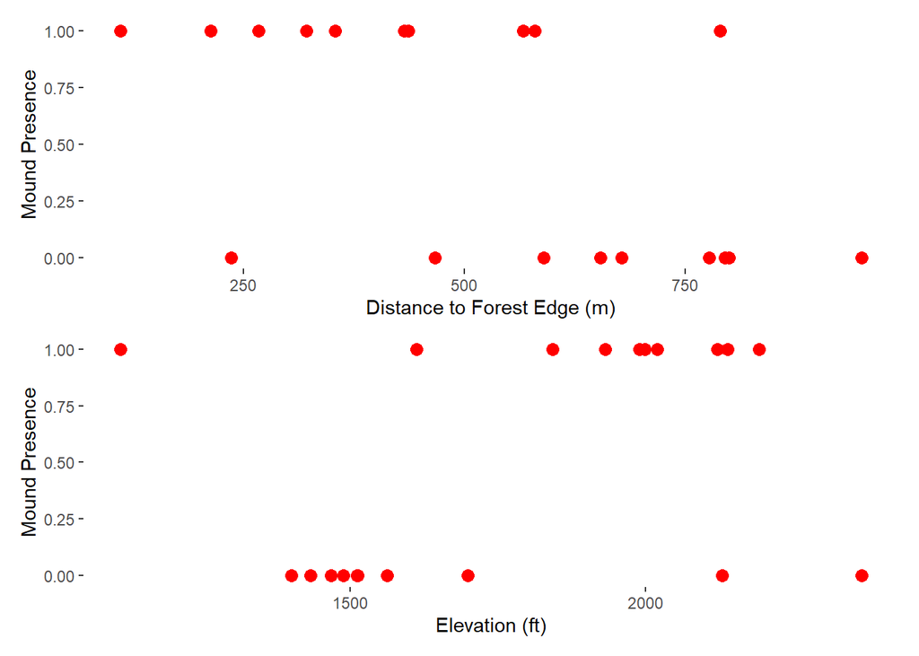

[figure not shown]

```r
p2 <- ggplot(ants, aes(distance.to.edge, presence,)) +
  geom_point(size = 3, color = "red") +
  xlab("Distance to Forest Edge (m)") +
  ylab("Mound Presence") +
  theme(panel.grid.major = element_blank(),
        panel.grid.minor = element_blank(),
        panel.background = element_blank())

p3 <- ggplot(ants, aes(Elevation, presence,)) +
  geom_point(size = 3, color = "red") +
  xlab("Elevation (ft)") +
  ylab("Mound Presence") +
  theme(panel.grid.major = element_blank(),
        panel.grid.minor = element_blank(),
        panel.background = element_blank())

p2 / p3
```

The goal of this second study was to investigate what influences the over-wintering survival of tri-colored bats in North America. A total of 12 bats were surveyed (6 that survived the winter and 6 that did not). The data includes one response variable: survival, and four predictor variables: winter duration (days), sex, mass (g), and elevation.

```r
bats <- read.csv("bats.csv")
bats$survival <- as.numeric(bats$survival)
bats$winter.duration <- as.numeric(bats$winter.duration)
bats$mass <- as.numeric(bats$mass)
bats$sex <- as.numeric(bats$sex)
bats$elevation <- as.numeric(bats$elevation)
```

Firstly, I checked for co-linearity among the four predictor variables.

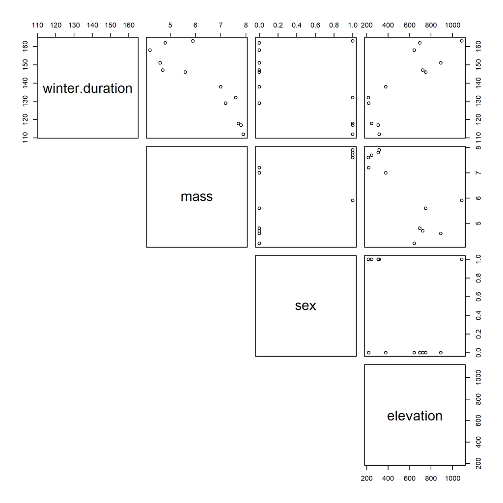

```r
pairs(bats[,2:5], lower.panel = NULL)
```

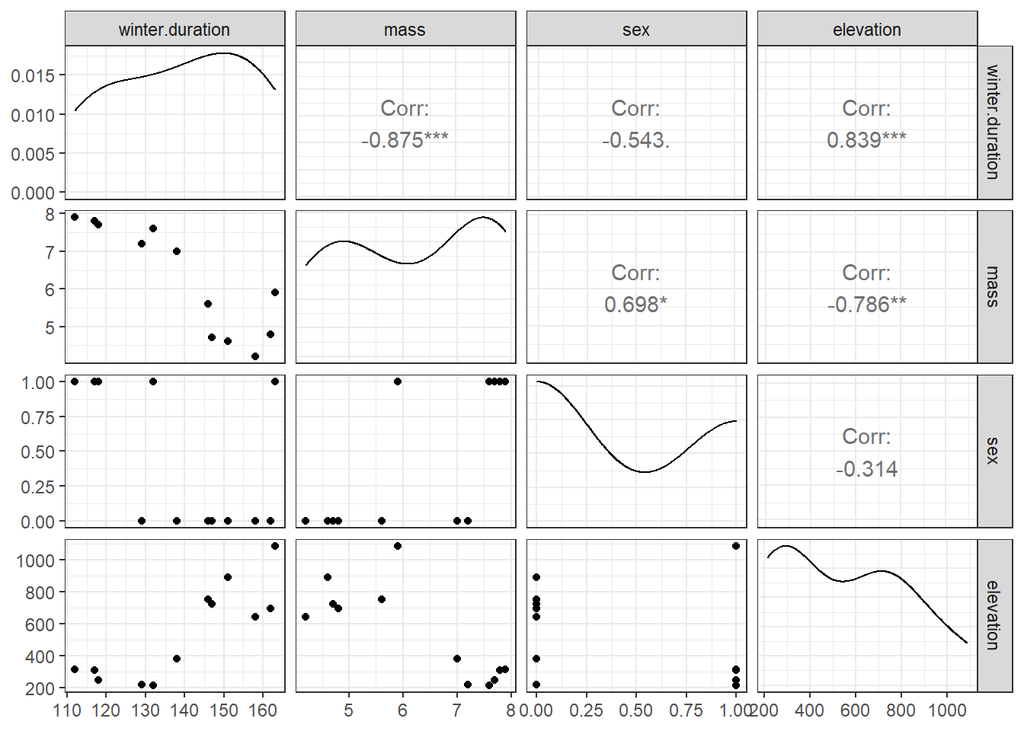

```r
ggpairs(bats, columns = 2:5) + theme_bw()
```

Elevation and winter are highly correlated as expected because higher elevations generally have more severe and longer winters. but for the purposes of this assignment, I chose to ignore it and run my candidate models next. (Note: Since this response variable was also binary, I had to run a generalized linear model)

```r
mod5 <- glm(survival ~ winter.duration + mass + elevation, family = binomial(link = "logit"), data = bats)
mod6 <- glm(survival ~ sex + winter.duration, family = binomial(link = "logit"), data = bats)
mod7 <- glm(survival ~ winter.duration + elevation, family = binomial(link = "logit"), data = bats)
mod8 <- glm(survival ~ winter.duration, family = binomial(link = "logit"), data = bats)
```

I then used the `model.sel` function to conduct model selection.

```r
out.put2 <- model.sel(mod5, mod6, mod7, mod8)
out.put2
```

```
## Model selection table
##       (Int)      elv   mss wnt.drt    sex          family df logLik AICc delta
## mod8  801.3                -5.6430        binomial(logit)  2      0  5.3  0.00
## mod7  171.1 -0.11540       -0.7589        binomial(logit)  3      0  9.0  3.67
## mod6  808.9                -5.6960 -32.12 binomial(logit)  3      0  9.0  3.67
## mod5 -213.4 -0.06622 21.09  0.8286        binomial(logit)  4      0 13.7  8.38
##      weight
## mod8  0.749
## mod7  0.120
## mod6  0.120
## mod5  0.011
## Models ranked by AICc(x)
```

Looks like model 8 containing an intercept (Int) and winter duration (wnt.drt) is best with a weight of 0.749. It is 0.749/0.120 = 6.24 times more likely to be the best explanation (hypothesis) for survival.

I then used the `subset` function to select the models that meet the criteria of having a delta value <5.

```r
subset(out.put2, delta <5)
```

```
## Model selection table
##      (Int)     elv wnt.drt    sex          family df logLik AICc delta weight
## mod8 801.3         -5.6430        binomial(logit)  2      0  5.3  0.00  0.758
## mod7 171.1 -0.1154 -0.7589        binomial(logit)  3      0  9.0  3.67  0.121
## mod6 808.9         -5.6960 -32.12 binomial(logit)  3      0  9.0  3.67  0.121
## Models ranked by AICc(x)
```

To re-normalize the weights, I used Royall’s 1/8 rule for strength of evidence.

```r
subset(out.put2, 1/8 < weight/max(out.put$weight))
```

```
## Model selection table
##      (Int)     elv wnt.drt    sex          family df logLik AICc delta weight
## mod8 801.3         -5.6430        binomial(logit)  2      0  5.3  0.00  0.758
## mod7 171.1 -0.1154 -0.7589        binomial(logit)  3      0  9.0  3.67  0.121
## mod6 808.9         -5.6960 -32.12 binomial(logit)  3      0  9.0  3.67  0.121
## Models ranked by AICc(x)
```

The weights did not change, so I tried selecting models with 95% cumulative weight.

```r
subset(out.put2, cumsum(out.put$weight) <= .95)
```

```
## Model selection table
##      (Int) wnt.drt          family df logLik AICc delta weight
## mod8 801.3  -5.643 binomial(logit)  2      0  5.3     0      1
## Models ranked by AICc(x)
```

We can see that this function has narrowed the models down to one.

I then cleaned up the data below.

```r
sel.table2 <-as.data.frame(out.put2)[6:10]
sel.table2[,2:3]<- round(sel.table2[,2:3],2)
sel.table2[,4:5]<- round(sel.table2[,4:5],3)
names(sel.table2)[2] = "K"
sel.table2
```

```
##               family K logLik   AICc delta
## mod8 binomial(logit) 2      0  5.333 0.000
## mod7 binomial(logit) 3      0  9.000 3.667
## mod6 binomial(logit) 3      0  9.000 3.667
## mod5 binomial(logit) 4      0 13.714 8.381
```

I then ran model selection sorted by BIC, CAICF, and AIC.

```r
model.sel(mod5, mod6, mod7, mod8, rank = BIC)
```

```
## Model selection table
##       (Int)      elv   mss wnt.drt    sex          family df logLik BIC delta
## mod8  801.3                -5.6430        binomial(logit)  2      0 5.0  0.00
## mod7  171.1 -0.11540       -0.7589        binomial(logit)  3      0 7.5  2.48
## mod6  808.9                -5.6960 -32.12 binomial(logit)  3      0 7.5  2.48
## mod5 -213.4 -0.06622 21.09  0.8286        binomial(logit)  4      0 9.9  4.97
##      weight
## mod8  0.602
## mod7  0.174
## mod6  0.174
## mod5  0.050
## Models ranked by BIC(x)
```

```r
model.sel(mod5, mod6, mod7, mod8, rank = CAICF)
```

```
## Model selection table
##       (Int)      elv   mss wnt.drt    sex          family df logLik CAICF delta
## mod5 -213.4 -0.06622 21.09  0.8286        binomial(logit)  4      0 -55.5  0.00
## mod6  808.9                -5.6960 -32.12 binomial(logit)  3      0 -49.9  5.57
## mod7  171.1 -0.11540       -0.7589        binomial(logit)  3      0 -36.4 19.04
## mod8  801.3                -5.6430        binomial(logit)  2      0 -30.0 25.44
##      weight
## mod5  0.942
## mod6  0.058
## mod7  0.000
## mod8  0.000
## Models ranked by CAICF(x)
```

```r
AIC(mod5, mod6, mod7, mod8)
```

```
##      df AIC
## mod5  4   8
## mod6  3   6
## mod7  3   6
## mod8  2   4
```

Next, I ran the importance weights for individual predictor variables.

```r
importance(out.put2)
```

```
##                      winter.duration elevation sex  mass
## Sum of weights:      1.00            0.13      0.12 0.01
## N containing models:    4               2         1    1
```

Looking at the output above, there is plenty of evidence for *winter duration* (weight is one), but much less for *elevation*, *sex*, and *mass*.

I then used the function `model.avg` to model average using all candidate models.

```r
MA.ests2 <- model.avg(out.put2, revised.var = TRUE)
MA.ests2
```

```
##
## Call:
## model.avg(object = out.put2, revised.var = TRUE)
##
## Component models:
## '3'   '13'  '34'  '123'
##
## Coefficients:
##        (Intercept) winter.duration   elevation        sex       mass
## full      715.2594       -4.991309 -0.01457815  -3.847228  0.2391658
## subset    715.2594       -4.991309 -0.11119002 -32.122010 21.0886169
```

I then plotted the “best” model.

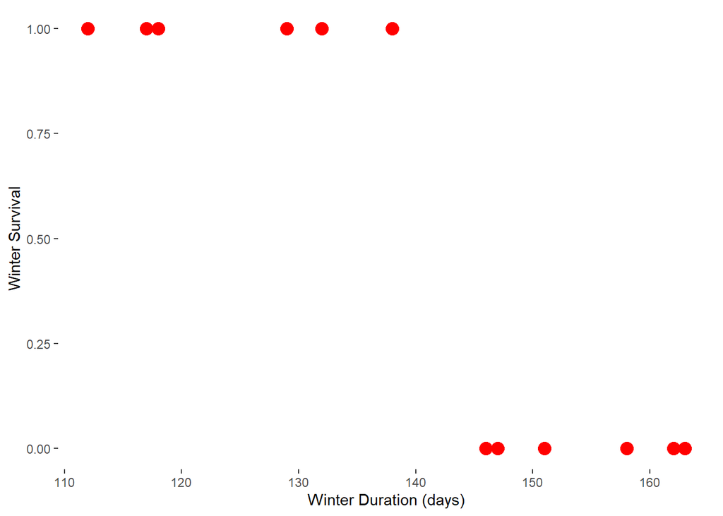

```r
p4 <- ggplot(bats, aes(winter.duration, survival)) +
  geom_point(color = "red", size = 4) +
  xlab("Winter Duration (days)") +
  ylab("Winter Survival") +
  theme(panel.grid.major = element_blank(),
        panel.grid.minor = element_blank(),
        panel.background = element_blank())

p4
```

Lastly, I plotted the competitive variables just for comparison.

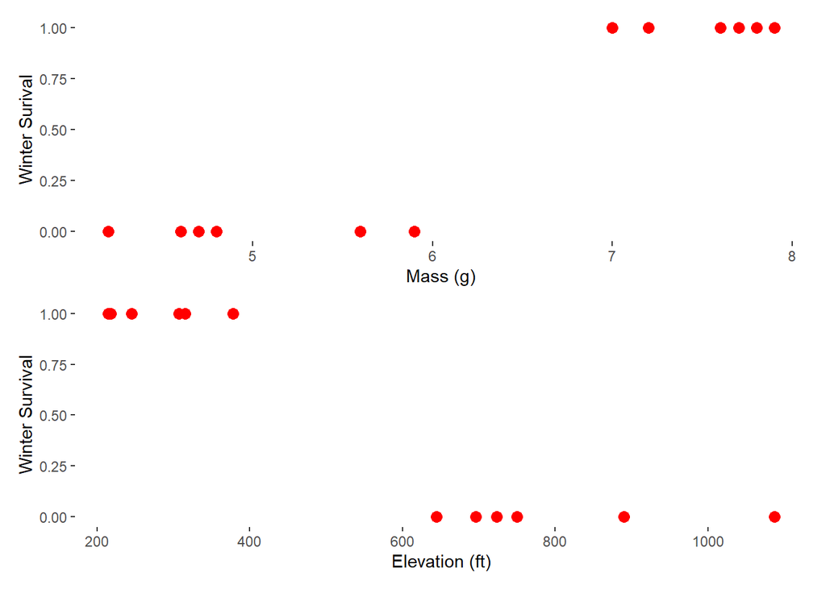

```r
p5 <- ggplot(bats, aes(mass, survival,)) +
  geom_point(size = 3, color = "red") +
  xlab("Mass (g)") +
  ylab("Winter Surival") +
  theme(panel.grid.major = element_blank(),
        panel.grid.minor = element_blank(),
        panel.background = element_blank())

p6 <- ggplot(bats, aes(elevation, survival,)) +
  geom_point(size = 3, color = "red") +
  xlab("Elevation (ft)") +
  ylab("Winter Survival") +
  theme(panel.grid.major = element_blank(),
        panel.grid.minor = element_blank(),
        panel.background = element_blank())

p5 / p6
```